# For loops and the apply family

Stephanie Thiede

11/15/2019

### 1. R basics - vectors, matrices, lists, logicals

#### A. Vectors - 1D arrays:

##### Initialize a vector

Two examples of how to initialize a vector

```r
my_vec = c(1,2,3,4,5,6,7,8,9,10)
my_vec
```

```
##  [1]  1  2  3  4  5  6  7  8  9 10
```

```r
my_vec = 1:10
my_vec
```

```
##  [1]  1  2  3  4  5  6  7  8  9 10
```

##### Initialize an empty vector

How to initialize an empty vector, to store things in later

```r
my_vec = vector(mode = 'numeric', length = 10 )
my_vec
```

```
##  [1] 0 0 0 0 0 0 0 0 0 0
```

#### B. Matrices/data frames - 2D arrays:

##### Initialize a matrix

Initialize a matrix called my_mat

```r
my_mat = matrix(1:10, ncol = 2, nrow = 5)
my_mat
```

```
##      [,1] [,2]
## [1,]    1    6
## [2,]    2    7
## [3,]    3    8
## [4,]    4    9
## [5,]    5   10
```

```r
class(my_mat)
```

```
## [1] "matrix"
```

Name the rows and columns using colnames() and row.names()

```r
colnames(my_mat) = c('A', 'B')
row.names(my_mat) = c('Sample1', 'Sample2', 'Sample3', 'Sample4', 'Sample5')

my_mat
```

```
##         A  B
## Sample1 1  6
## Sample2 2  7
## Sample3 3  8
## Sample4 4  9
## Sample5 5 10
```

Get the dimensions of my_mat. Dimensions are reported as c(row, column) where numbers of rows in the first bin, and number of columns in the second bin

```r
dim(my_mat)
```

```
## [1] 5 2
```

Can also ask for the number of rows and number of columns directly with ncol() and nrow()

```r
ncol(my_mat)
```

```
## [1] 2
```

```r
nrow(my_mat)
```

```
## [1] 5
```

Can see the column names and row names of my_mat with rownames() and colnames()

```r
#get the column names of my_mat
colnames(my_mat)
```

```
## [1] "A" "B"
```

```r
#get the row names of my_mat
rownames(my_mat)
```

```
## [1] "Sample1" "Sample2" "Sample3" "Sample4" "Sample5"
```

##### Access rows/columns in matrices

Format is: my_mat[row, column]

Can access with numeric indices

```r
# row 2, column 1
my_mat[2,1]
```

```
## [1] 2
```

Can access with row names and column names

```r
# row 2, column 1
my_mat['Sample2','A']
```

```
## [1] 2
```

Get all rows, 2nd column. Don’t specify a row, just use a comma

```r
# all rows, 2nd column
my_mat[,2]
```

```
## Sample1 Sample2 Sample3 Sample4 Sample5
##       6       7       8       9      10
```

Get all columns, 1st row. Don’t specify a column, just use a comma

```r
# all columns, 1st row
my_mat[1,]
```

```
## A B
## 1 6
```

##### C. Data frames

Initialize a data frame

```r
my_df = data.frame(A = c(1,2,3,4,5), B = c(6,7,8,9,10), row.names = c('Sample1', 'Sample2', 'Sample3', 'Sample4', 'Sample5'))

my_df
```

```
##         A  B
## Sample1 1  6
## Sample2 2  7
## Sample3 3  8
## Sample4 4  9
## Sample5 5 10
```

```r
# get the class -- data.frame
class(my_df)
```

```
## [1] "data.frame"
```

Indexing dataframes is the same as matrices, but you can also index the columns using the $.

3 ways to access column A, the first column

```r
my_df[,'A']
```

```
## [1] 1 2 3 4 5
```

```r
my_df[,1]
```

```
## [1] 1 2 3 4 5
```

```r
my_df$A #can't do this with matrices!
```

```
## [1] 1 2 3 4 5
```

#### D. Lists

Each element of a list can contain vectors, matrices, lists, etc. of any shape or size.

Here, we have a list where the first element will be a vector, the second is a matrix, and the third is a data.frame

```r
my_list = list(my_vec, my_mat, my_df)

my_list
```

```
## [[1]]
##  [1] 0 0 0 0 0 0 0 0 0 0
##
## [[2]]
##         A  B
## Sample1 1  6
## Sample2 2  7
## Sample3 3  8
## Sample4 4  9
## Sample5 5 10
##
## [[3]]
##         A  B
## Sample1 1  6
## Sample2 2  7
## Sample3 3  8
## Sample4 4  9
## Sample5 5 10
```

##### Accessing element of a list

Use double square brackets to access a list element. Here, we’re accessing the first element of my_list.

```r
my_list[[1]]
```

```
##  [1] 0 0 0 0 0 0 0 0 0 0
```

##### Acess content with a list element

Access the second element of the list

```r
my_list[[2]]
```

```
##         A  B
## Sample1 1  6
## Sample2 2  7
## Sample3 3  8
## Sample4 4  9
## Sample5 5 10
```

Then you can subset it with matrix subsetting (since its a matrix)

```r
my_list[[2]][1,1]
```

```
## [1] 1
```

```r
my_list[[2]]['Sample1','A']
```

```
## [1] 1
```

##### Subsetting a list

Subset a list with single square brackets. This will make your list a length of 2 – containing only the 1st and 3rd elements of my_list()

```r
my_list[c(1,3)]
```

```
## [[1]]
##  [1] 0 0 0 0 0 0 0 0 0 0
##
## [[2]]
##         A  B
## Sample1 1  6
## Sample2 2  7
## Sample3 3  8
## Sample4 4  9
## Sample5 5 10
```

#### E. Subsetting a data frame with logicals

Say, your samples in my_df came from the following sources: either dog or cat as such.

```r
sample_source = c('cat', 'dog', 'cat', 'cat', 'dog')
```

See how the length of sample_source is the same as the number of rows in my_df – as each sample is either from “dog” or “cat”

```r
length(sample_source)
```

```
## [1] 5
```

```r
dim(my_df)
```

```
## [1] 5 2
```

Create a logical vector – ask “where does sample source equal cat”. Will give TRUE when sample_source is cat and FALSE when sample_source is dog.

```r
sample_source == 'cat'
```

```
## [1]  TRUE FALSE  TRUE  TRUE FALSE
```

See that the class is a logical

```r
class(sample_source == 'cat')
```

```
## [1] "logical"
```

We can subset the column ‘A’ in my_df on cat samples using the logical vector.

```r
my_df$A[sample_source == 'cat']
```

```
## [1] 1 3 4
```

Similarily, we can subset my_df on the dog samples using another logical vector – and use comma to indicate we want all the columns.

```r
my_df[sample_source == 'dog',]
```

```
##         A  B
## Sample2 2  7
## Sample5 5 10
```

### 2.1 Iterating through vectors

### 2.1.1 Iterating through vectors with for loops

#### A. Structure of a for loop

for (thing in sequence){

do thing

}

#### B. Examples

Initialize vector of colors

```r
colors = c('red', 'blue', 'green')
```

Create function my_fav_col() which takes as input a string and outputs another string “My favorite color is ____”

```r
my_fav_col <- function(color){
  return(paste('My favorite color is', color))
}
```

Iterating through indexing

```r
for (i in 1:length(colors)){

  print( my_fav_col(colors[i]) )

}
```

```
## [1] "My favorite color is red"
## [1] "My favorite color is blue"
## [1] "My favorite color is green"
```

Iterating through a vector called colors

```r
for (thing in colors){

  print( my_fav_col(thing) )

}
```

```
## [1] "My favorite color is red"
## [1] "My favorite color is blue"
## [1] "My favorite color is green"
```

### 2.1.2 Iterating through vectors with sapply()

Pass each element of colors to our function, my_fav_col

```r
sapply(colors, my_fav_col)
```

```
##                          red                         blue
##   "My favorite color is red"  "My favorite color is blue"
##                        green
## "My favorite color is green"
```

### 2.2 Iterating through matrices

Recall my_mat

```r
my_mat
```

```
##         A  B
## Sample1 1  6
## Sample2 2  7
## Sample3 3  8
## Sample4 4  9
## Sample5 5 10
```

Our goal is to get the mean of each row. Let’s do so with both a for loop (2.2.1) and an apply statement (2.2.2)

### 2.2.1. Iterating through MATRICES with for loops

```r
for (i in 1:nrow(my_mat)){
  row = my_mat[i,]
  print(mean(row))
}
```

```
## [1] 3.5
## [1] 4.5
## [1] 5.5
## [1] 6.5
## [1] 7.5
```

### 2.2.2. Iterating through MATRICES with apply()

```r
apply(my_mat, 1, mean)
```

```
## Sample1 Sample2 Sample3 Sample4 Sample5
##     3.5     4.5     5.5     6.5     7.5
```

### 3. Vectorized vs. sapply vs. for loop

Say we have 100,000 circle radii (1-100,000) and we want to calculate the area of each circle.

```r
# Vector of circle radii
radii = 1:100000
```

Here’s our function to calculate the area of a circle:

```r
# Function for area of a circle
area_of_circle <- function(r){
  return(pi * r^2)
}
```

Here’s an example of running our function on one radius – a radius of 10

```r
# Example of using the function
area_of_circle(r = 10)
```

```
## [1] 314.1593
```

Let’s see how much time it takes to use 1) vectorized R code 2) sapply() statement versus 3) a for loop. We’ll run it N times to compare the trends.

```r
# initialize vectors to store run time
repeats = 40
time_vec = vector('numeric', length = repeats)
time_sapply = vector('numeric', length = repeats)
time_for = vector('numeric', length = repeats)
```

#### A. Vectorized

```r
for (i in 1:repeats){

  start = Sys.time()
  areas_method1 = area_of_circle(radii)
  end = Sys.time()

  time_vec[i] = as.numeric(end - start)
}
```

#### B. sapply()

```r
for (i in 1:repeats){

  start = Sys.time()
  areas_method2 = sapply(radii, area_of_circle)
  end = Sys.time()

  time_sapply[i] = as.numeric(end - start)
}
```

#### C. for loop

```r
for (j in 1:repeats){

  start = Sys.time()

  areas_method3 = vector(mode = 'numeric', length = length(radii))

  for (i in 1:length(radii)){
    areas_method3[i] = area_of_circle(radii[i])
    }

  end = Sys.time()

  time_for[j] = as.numeric(end - start)
}
```

#### D. Comparing speed for vectorized code, for loop, apply

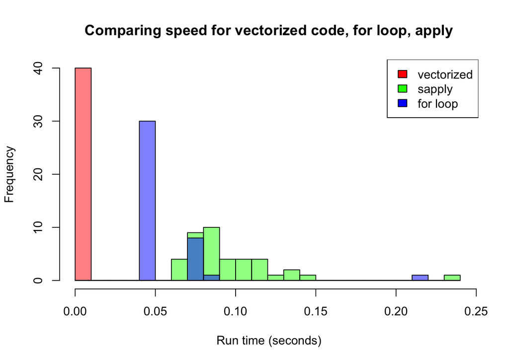

```r
max_val = max(c(time_vec, time_sapply, time_for)) + 0.01

hist(time_vec, col = rgb(1,0,0,0.5), breaks = seq(0,max_val, 0.01), xlim = c(0,max_val),
     main = 'Comparing speed for vectorized code, for loop, apply', xlab = 'Run time (seconds)')
hist(time_sapply, col = rgb(0,1,0,0.5), breaks = seq(0,max_val, 0.01),add = TRUE)
hist(time_for, col = rgb(0,0,1,0.5), breaks = seq(0,max_val, 0.01),add = TRUE)
legend('topright', fill = c('red', 'green', 'blue'), legend = c('vectorized', 'sapply', 'for loop'))
```

To summarize:

- vectorized code is faster than sapply() and for loops
- for loops and sapply() are similar in speed, depending on the length of the vector and the task
- for loops completes same task in multiple lines of code, vectorization & sapply in 1 line of code so you might want to use an apply family function for clarigy

Let’s explore with examples.

### 4. Looping over a vector or list: sapply() or lapply()

Read in TV ratings data

```r
tv_data = read.csv('data/IMDb_Economist_tv_ratings.csv', stringsAsFactors = FALSE)
```

Let’s take a look at the TV ratings data

```r
head(tv_data, 15)
```

```
##      titleId seasonNumber          title       date av_rating share
## 1  tt2879552            1       11.22.63 2016-03-10    8.4890  0.51
## 2  tt3148266            1     12 Monkeys 2015-02-27    8.3407  0.46
## 3  tt3148266            2     12 Monkeys 2016-05-30    8.8196  0.25
## 4  tt3148266            3     12 Monkeys 2017-05-19    9.0369  0.19
## 5  tt3148266            4     12 Monkeys 2018-06-26    9.1363  0.38
## 6  tt1837492            1 13 Reasons Why 2017-03-31    8.4370  2.38
## 7  tt1837492            2 13 Reasons Why 2018-05-18    7.5089  2.19
## 8  tt0285331            1             24 2002-02-16    8.5641  6.67
## 9  tt0285331            2             24 2003-02-09    8.7028  7.13
## 10 tt0285331            3             24 2004-02-09    8.7173  5.88
## 11 tt0285331            4             24 2005-03-08    8.5610  3.48
## 12 tt0285331            5             24 2006-03-10    8.7828  2.15
## 13 tt0285331            6             24 2007-03-08    8.3522  2.23
## 14 tt0285331            7             24 2009-03-10    8.4922  2.04
```

[output cut: 17 more lines]

Say we wanted to figure out what the max number of seasons was for each show. We could approach this with a for loop or an sapply. Let’s do both and compare.

For loop.

```r
#initialize vector to store max season number in
max_season = rep(NA, length(unique(tv_data$title)))

# loop through indices 1 to length of the unique TV show titles
  # access the show name (show)
  # get all the seasons for the show (all_season_numbers)
  # get the max season number and store in max_season[index]

#name storage vector to be the show title
for (i in 1:length(unique(tv_data$title))){
  show = unique(tv_data$title)[i]
  all_season_numbers = tv_data$seasonNumber[tv_data$title == show]
  max_season[i] = max(all_season_numbers)
}
names(max_season) = unique(tv_data$title)
```

```r
head(max_season)
```

```
##             11.22.63           12 Monkeys       13 Reasons Why
##                    1                    4                    2
##                   24           24: Legacy 24: Live Another Day
##                    8                    1                    1
```

sapply version

```r
max_season = sapply(unique(tv_data$title), function(show){
   all_season_numbers = tv_data$seasonNumber[tv_data$title == show]
   max(all_season_numbers)
})
```

#### sapply() will output your data in the simplest form it can. Here, we see if outputted a vector because we were trying to access 1 value (the max season number) from each tv show title

```r
head(max_season)
```

```
##             11.22.63           12 Monkeys       13 Reasons Why
##                    1                    4                    2
##                   24           24: Legacy 24: Live Another Day
##                    8                    1                    1
```

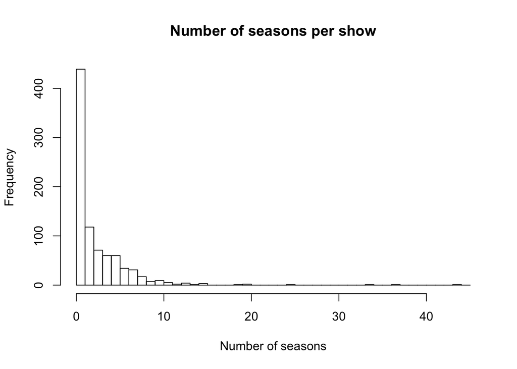

```r
hist(max_season, breaks = seq(0,45,1), main = 'Number of seasons per show', xlab = 'Number of seasons')
```

#### Let’s explore some other ways sapply() can output your data. Here, let’s find the average rating of each season of a show

```r
avg_rating_per_show = sapply(unique(tv_data$title), function(show){
  tv_data$av_rating[tv_data$title == show]
})
head(avg_rating_per_show)
```

```
## $`11.22.63`
## [1] 8.489
##
## $`12 Monkeys`
## [1] 8.3407 8.8196 9.0369 9.1363
##
## $`13 Reasons Why`
## [1] 8.4370 7.5089
##
## $`24`
## [1] 8.5641 8.7028 8.7173 8.5610 8.7828 8.3522 8.4922 8.4744
##
## $`24: Legacy`
## [1] 7.2044
##
## $`24: Live Another Day`
## [1] 8.899
```

#### You can see sapply() outputted a list because each tv show had a variable number of seasons and thus a variable number of ratings. Thus, the simplest data structure was a list.

#### Let’s look at anther example – Here, we will first subset on those with 2 seasons (or rather, 2 entries in the dataset):

Use an sapply() to figure out how many seasons/entries each show has

```r
num_seasons = sapply(unique(tv_data$title), function(show){
  length(tv_data$seasonNumber[tv_data$title == show])
})
```

Subset on the show titles with 2 seasons/entries

```r
two_seasons = unique(tv_data$title)[num_seasons == 2]
```

Find the average rating for the shows with two seasons

```r
avg_rating_two_seasons = sapply(two_seasons, function(show){
  (tv_data$av_rating[tv_data$title == show])
})

head(t(avg_rating_two_seasons))
```

```
##                                  [,1]   [,2]
## 13 Reasons Why                 8.4370 7.5089
## 7th Heaven                     7.7000 6.3000
## A Series of Unfortunate Events 8.1052 8.2873
## Alphas                         7.6436 7.8699
## American Crime Story           8.7267 8.3940
## American Gothic                7.8000 7.5350
```

#### Because every show had 2 data points, a matrix was the simplest output

#### We can control output with lapply() – lapply() will ALWAYS output a list.

```r
avg_rating_two_seasons = lapply(two_seasons, function(show){
  (tv_data$av_rating[tv_data$title == show])
})

head(avg_rating_two_seasons)
```

```
## [[1]]
## [1] 8.4370 7.5089
##
## [[2]]
## [1] 7.7 6.3
##
## [[3]]
## [1] 8.1052 8.2873
##
## [[4]]
## [1] 7.6436 7.8699
##
## [[5]]
## [1] 8.7267 8.3940
##
## [[6]]
## [1] 7.800 7.535
```

### We can use tapply() to summarize data

Here, we want to know what is the average rating per show across all seasaons

```r
avg_rating_per_title = tapply(tv_data$av_rating, tv_data$title, mean)
head(avg_rating_per_title)
```

```
##             11.22.63           12 Monkeys       13 Reasons Why
##             8.489000             8.833375             7.972950
##                   24           24: Legacy 24: Live Another Day
##             8.580850             7.204400             8.899000
```

### 5. Looping over a matrix/data.frame: apply()

Now let’s play with apply statements with another dataset – bacterial growth curve data.

#### Growth curve example

```r
growth = read.csv('data/mock_growth_curve_data.csv', row.names = 1)
```

Let’s take a look at how the data is organized. We have 8 wells growing bacteria, where each well is a column. Rows indicate time, and time was taken every 15 minutes.

```r
head(growth)
```

```
##    Well1 Well2 Well3 Well4 Well5 Well6 Well7 Well8
## 0  0.122 0.098 0.111 0.116 0.181 0.180 0.187 0.184
## 15 0.090 0.091 0.090 0.090 0.161 0.161 0.159 0.159
## 30 0.092 0.093 0.092 0.092 0.186 0.186 0.185 0.185
## 45 0.097 0.097 0.097 0.097 0.227 0.228 0.227 0.228
## 60 0.105 0.105 0.105 0.104 0.299 0.300 0.300 0.301
## 75 0.118 0.116 0.118 0.117 0.394 0.394 0.395 0.395
```

Say we want to take the mean at each timepoint. We can use apply, loop over the rows (1), and use the function mean()

```r
mean_growth = apply(growth, 1, mean)
```

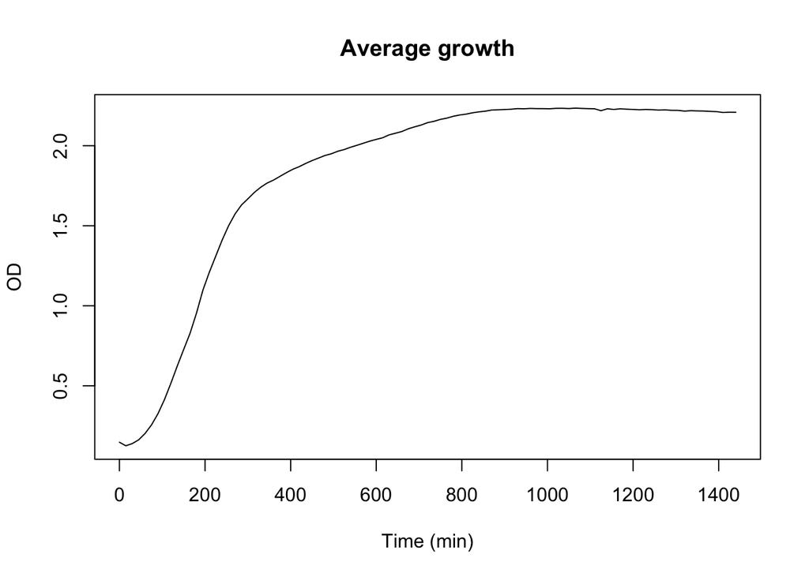

```r
plot(row.names(growth), mean_growth, type = 'l', ylab = 'OD', xlab = 'Time (min)', main = 'Average growth')
```

We can also plot our curves with apply. Here, we can plot each well on its own plot.

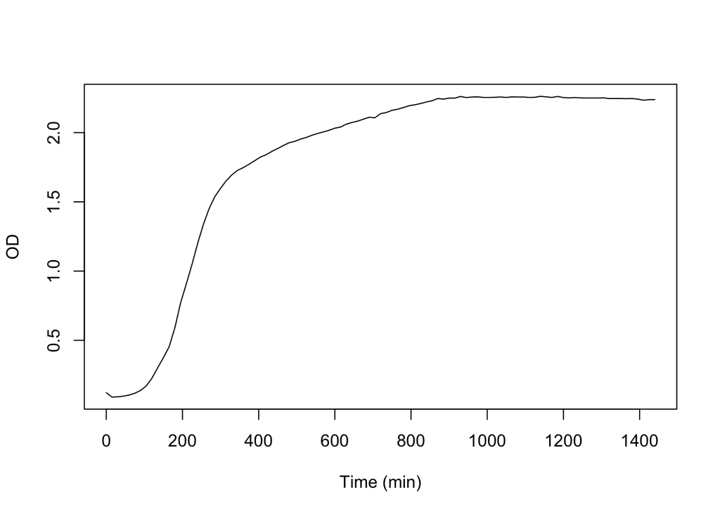

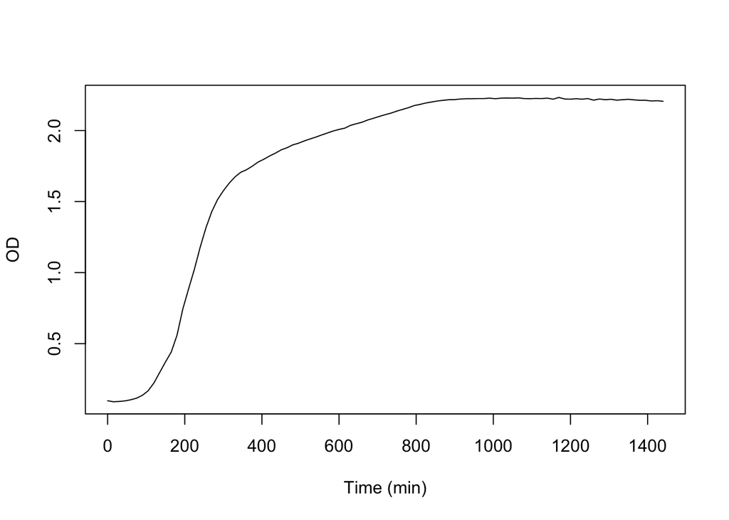

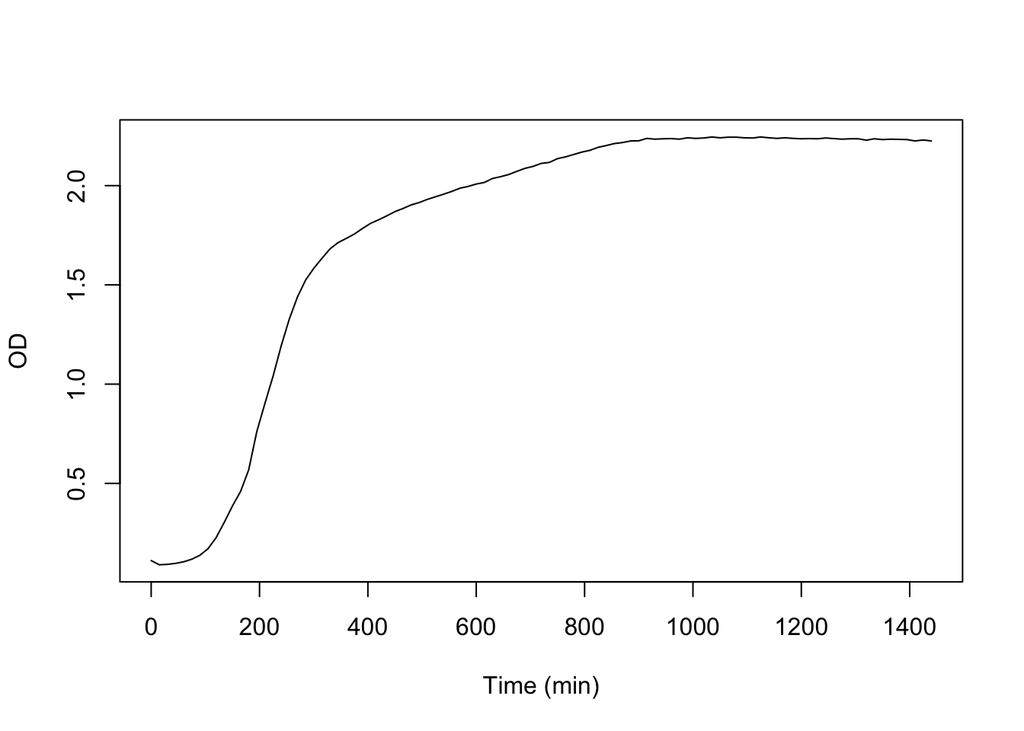

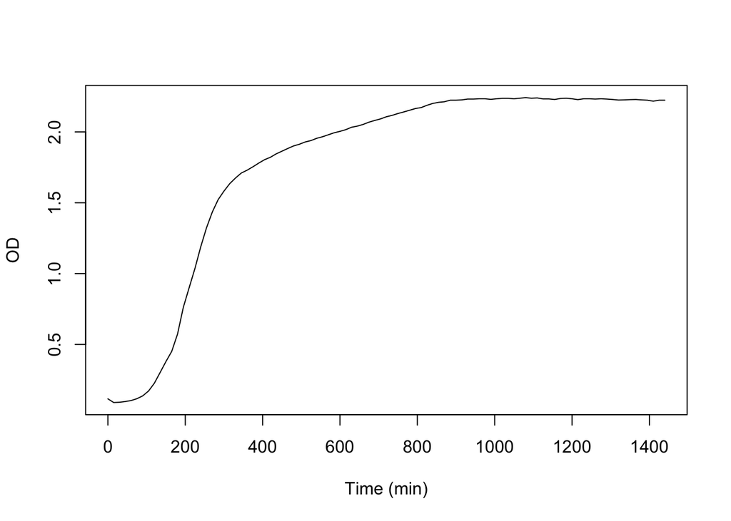

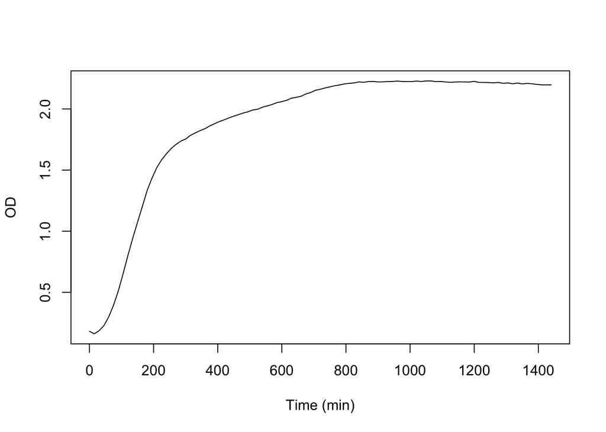

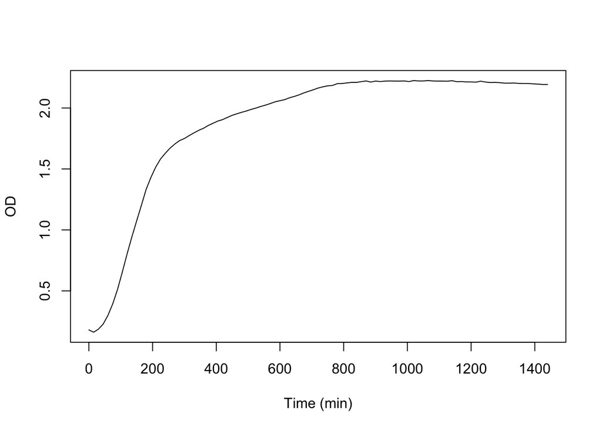

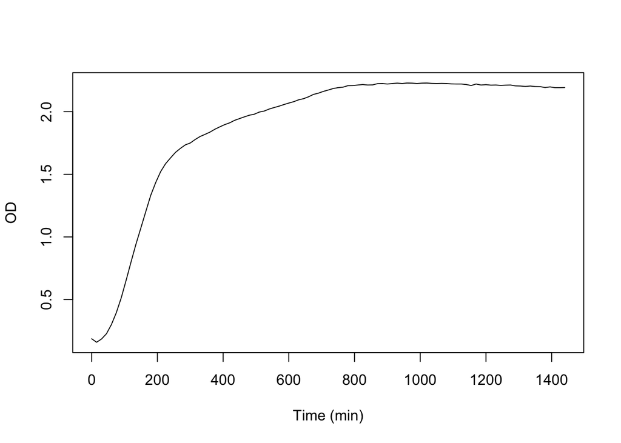

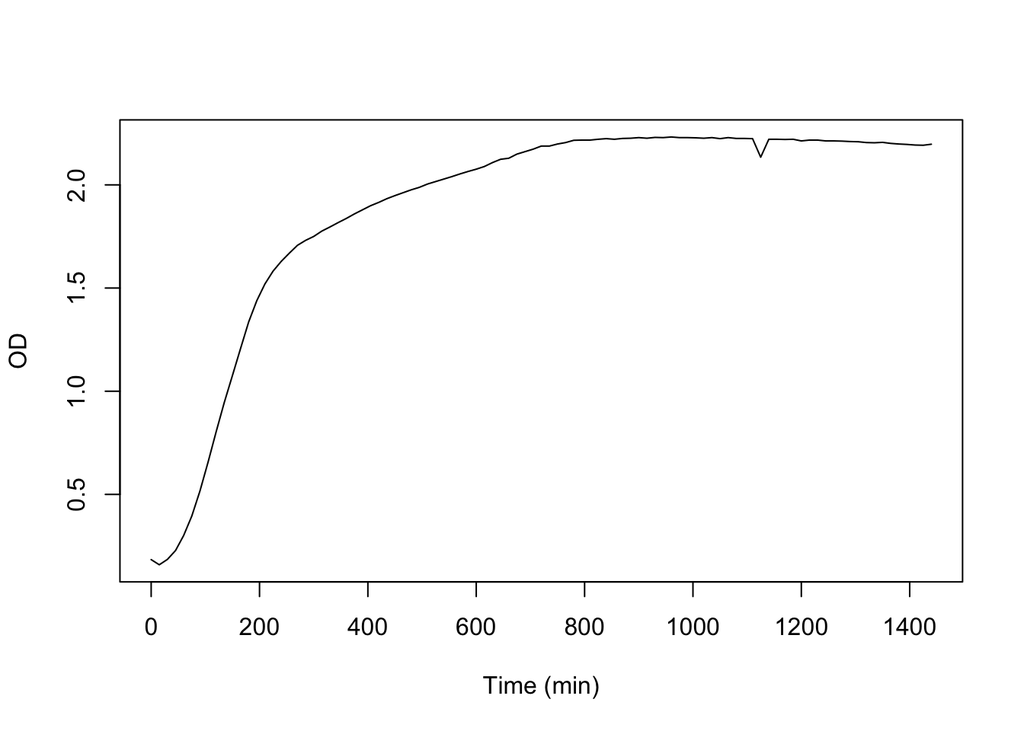

```r
apply(growth, 2, function(col){
  plot(row.names(growth), col, type = 'l', ylab = 'OD', xlab = 'Time (min)')
})
```

We can also plot all curves on the same plot

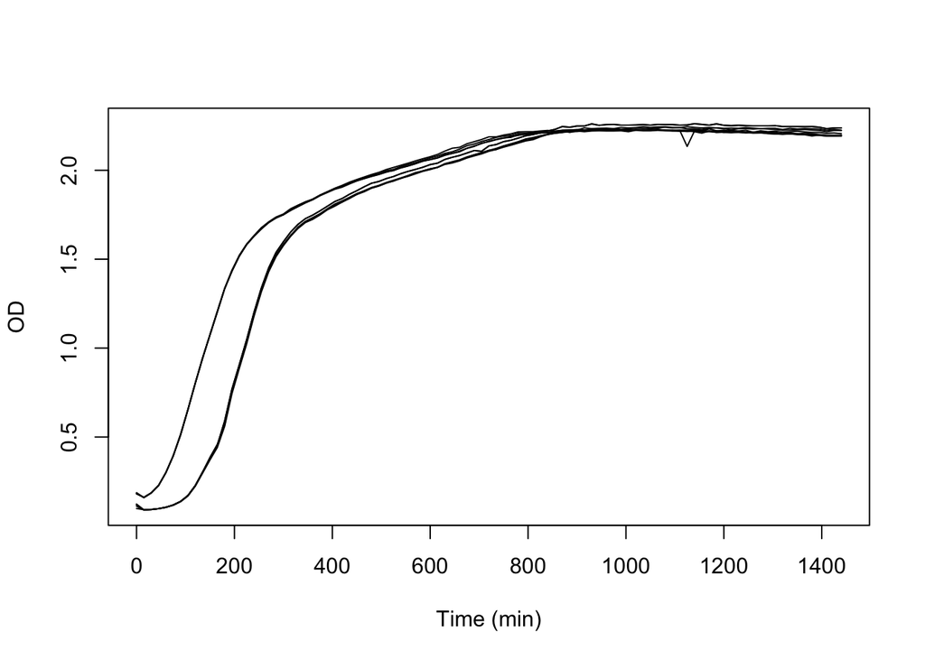

```r
plot(row.names(growth), growth$Well1, type = 'l', ylab = 'OD', xlab = 'Time (min)')
apply(growth, 2, function(col){
  lines(row.names(growth), col)
})
```

It looks like there are two growth patterns. Let’s explore by plotting the max difference at each time point.

```r
max_difference = apply(growth, 1, function(row){
  max(row) - min(row)
})
```

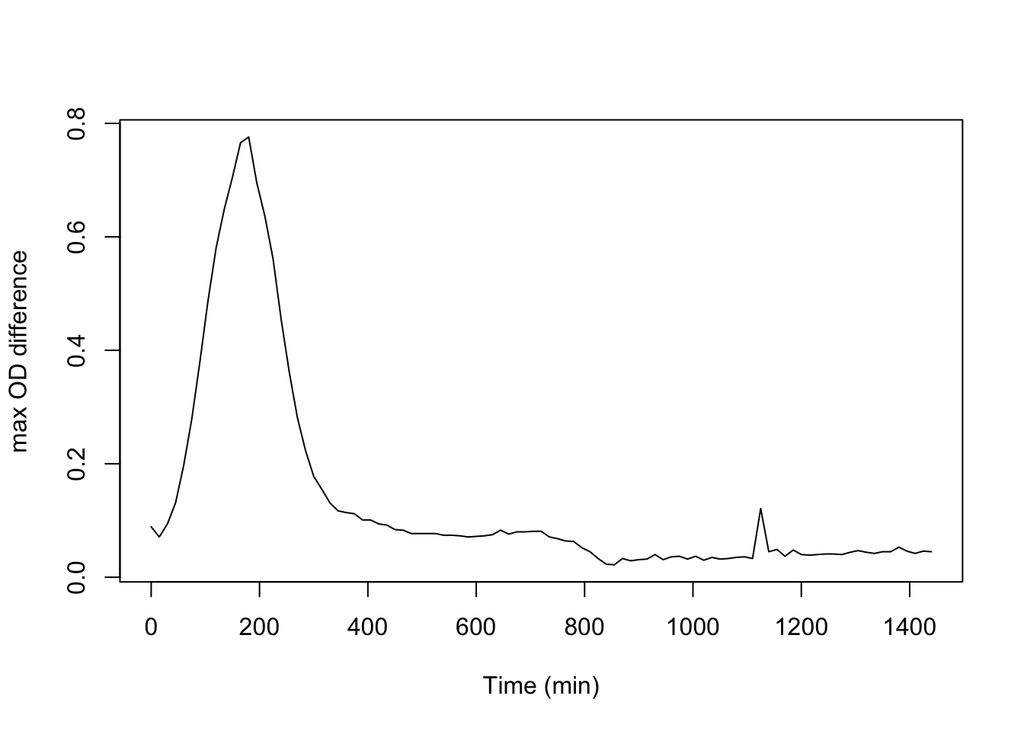

```r
plot(row.names(growth), max_difference, type = 'l', ylab = 'max OD difference', xlab = 'Time (min)')
```

### 6. Faster looping with future.apply

Here’s a [Data Camp tutorial](https://campus.datacamp.com/courses/parallel-programming-in-r/foreach-futureapply-and-load-balancing?ex=9) to learn more about paralell programming in R – specifically future and future.apply()